# Regresja logistyczna i szukanie trendu

Adam Michalski

```r
library(readr)
purchases <- read_csv2('Raty.csv', col_types = cols(
  Raty = col_factor()))
```

```
## ℹ Using "','" as decimal and "'.'" as grouping mark. Use `read_delim()` for more control.
```

```r
str(purchases)
```

```
## spc_tbl_ [127 × 4] (S3: spec_tbl_df/tbl_df/tbl/data.frame)
##  $ Dochody: num [1:127] 3022 1793 3069 2523 1431 ...
##  $ Wiek   : num [1:127] 49 21 21 22 34 54 55 38 44 45 ...
##  $ Wydatek: num [1:127] 973 665 1533 861 379 ...
##  $ Raty   : Factor w/ 2 levels "N","T": 1 2 1 1 1 2 1 2 1 2 ...
##  - attr(*, "spec")=
##   .. cols(
##   ..   Dochody = col_double(),
##   ..   Wiek = col_double(),
##   ..   Wydatek = col_double(),
##   ..   Raty = col_factor(levels = NULL, ordered = FALSE, include_na = FALSE)
##   .. )
##  - attr(*, "problems")=<externalptr>
```

```r
reg <- glm(Raty ~ Wiek, data = purchases, family = binomial)
summary(reg)
```

```
##
## Call:
## glm(formula = Raty ~ Wiek, family = binomial, data = purchases)
##
## Coefficients:
##             Estimate Std. Error z value Pr(>|z|)
## (Intercept)  0.85027    0.67377   1.262    0.207
## Wiek        -0.02157    0.01618  -1.333    0.182
##
## (Dispersion parameter for binomial family taken to be 1)
##
##     Null deviance: 176.05  on 126  degrees of freedom
## Residual deviance: 174.25  on 125  degrees of freedom
## AIC: 178.25
##
## Number of Fisher Scoring iterations: 4
```

Na podstawie p-wartości 0.182 nie mamy podstaw do odrzucenia hipotezy o zerowaniu się współczynnika zależności decyzji o ratach w zależności od wieku, więc nie mamy podstaw do rozważania istotnej zależności między tymi dwoma zmiennymi.

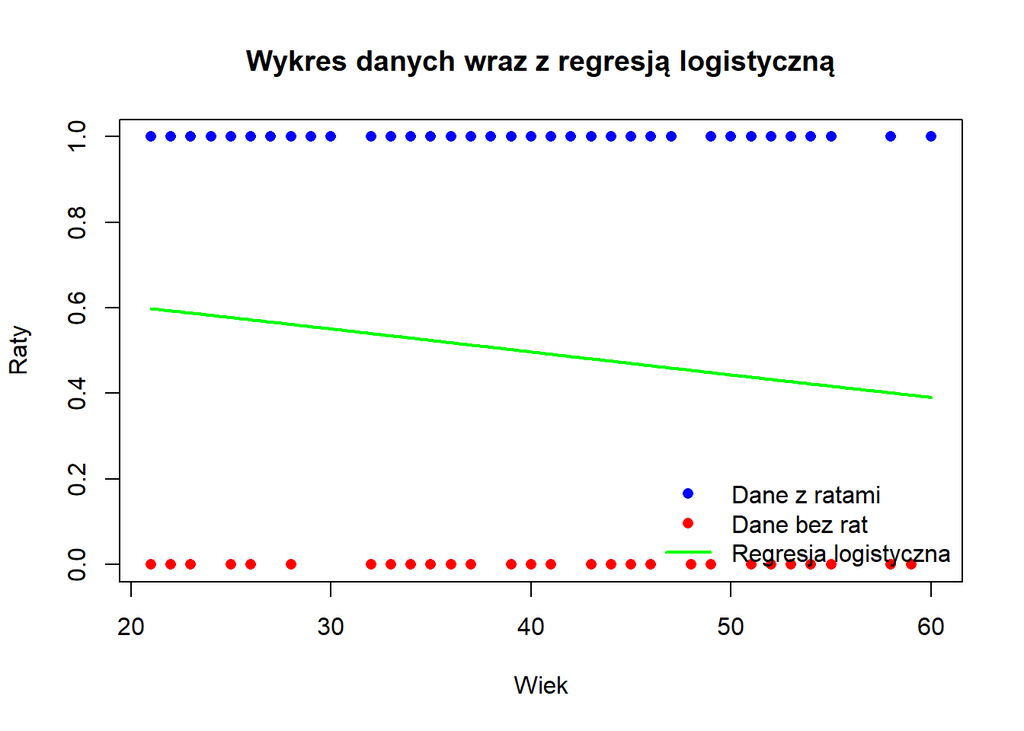

```r
plot(purchases$Wiek, as.numeric(purchases$Raty)-1,
     col = ifelse(purchases$Raty == "T", "blue", "red"),
     pch = 16,
     xlab = "Wiek",
     ylab = "Raty",
     main = "Wykres danych wraz z regresją logistyczną")
legend("bottomright",
       legend = c("Dane z ratami", "Dane bez rat", "Regresja logistyczna"),
       col = c("blue", "red", "green"),
       pch = c(16, 16, NA),
       lty = c(NA, NA, 1),
       lwd = c(NA, NA, 2),
       bty = "n")
wiek_range <- seq(min(purchases$Wiek), max(purchases$Wiek), length.out = 300)
prediction_data <- data.frame(Wiek = wiek_range)
predicted_probs <- predict(reg, newdata = prediction_data, type = "response")

lines(wiek_range, predicted_probs, lwd = 2, col = "green")
```

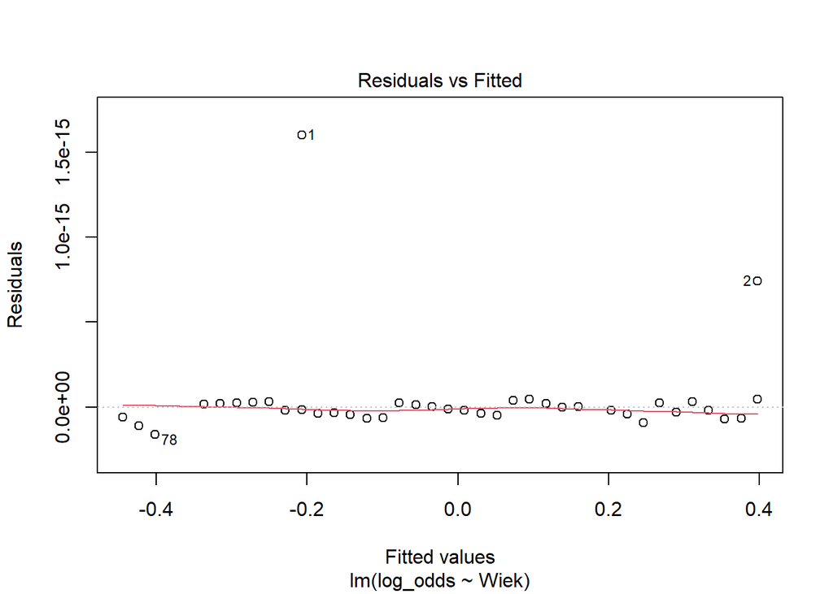

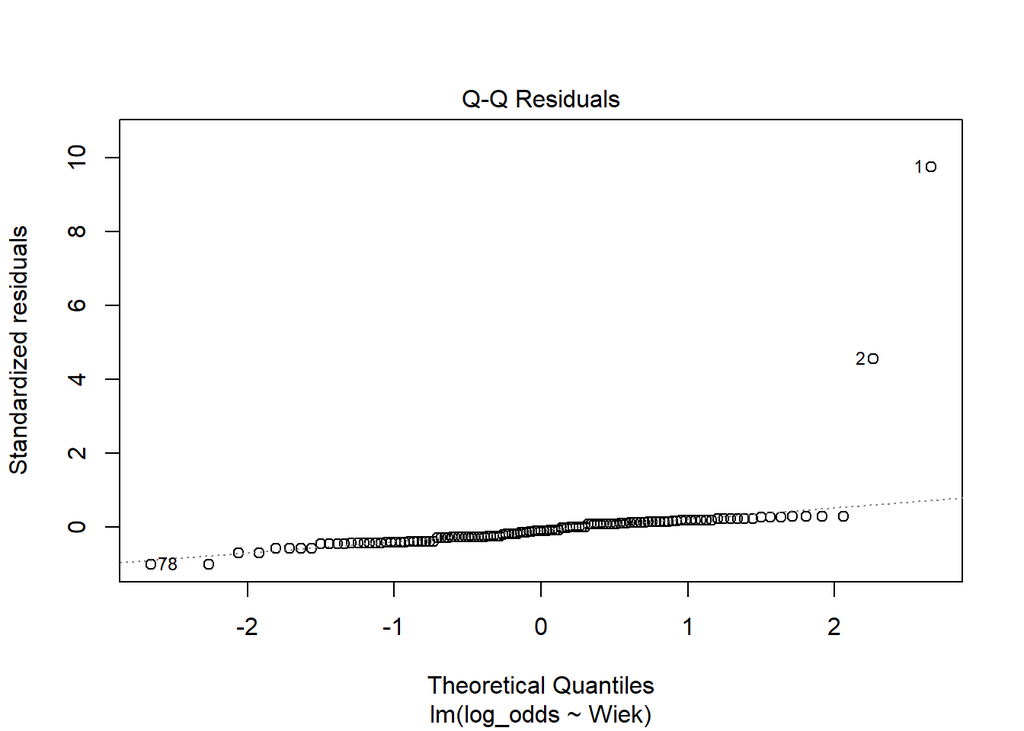

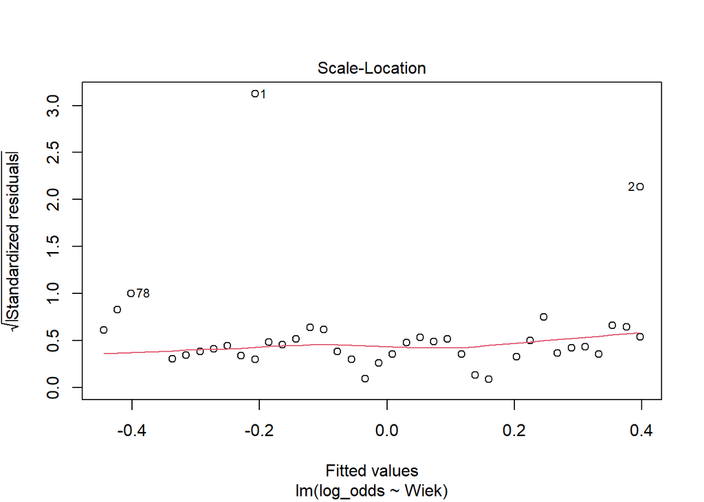

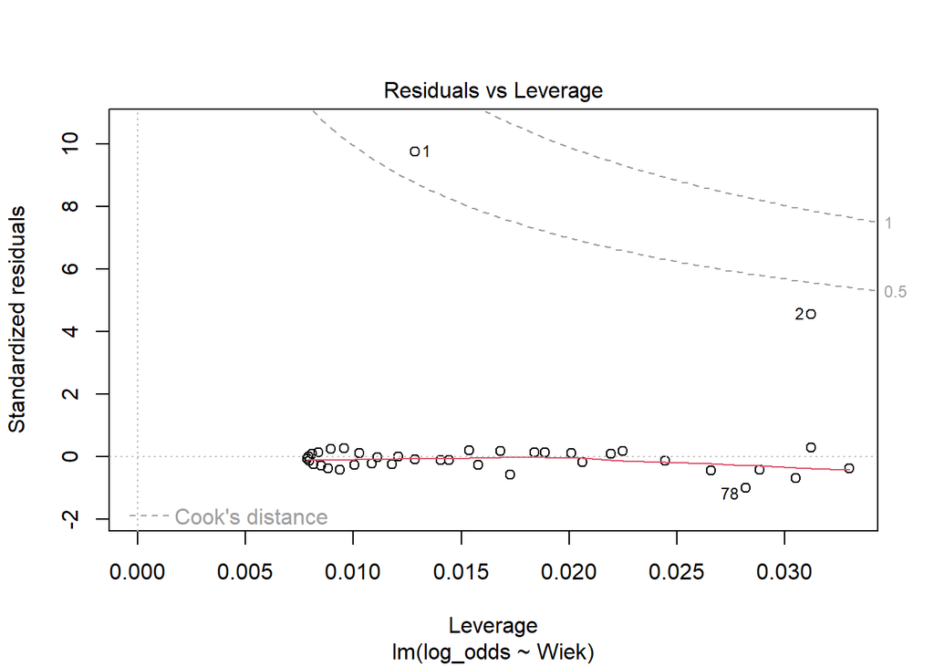

```r
log_odds <- predict(reg, type = "link")

purchases$log_odds <- predict(reg, type = "link")
linear_model <- lm(log_odds ~ Wiek, data = purchases)
plot(linear_model)
```

```r
shapiro.test(linear_model$residuals)
```

```
##
##  Shapiro-Wilk normality test
##
## data:  linear_model$residuals
## W = 0.30888, p-value < 2.2e-16
```

Z pierwszego wykresu widać iż krzywa logistyczna przypomina prostą, co przemawia za brakiem silnej zależności między decyzją o zakupie na raty a wiekiem. Niestety wykresy diagnostyczne dla modelu liniowego log odds wskazują na silne odstawanie pewnych punktów danych oraz test shapiro wilka odrzuca hipotezę o normalności reszt, więc model nie spełnia założeń teoretycznych.

```r
regression_test <- read_csv2('test_regresji.csv')
```

```
## ℹ Using "','" as decimal and "'.'" as grouping mark. Use `read_delim()` for more control.
```

```
## ──────────────────────────────────────────────────────── Delimiter: ";" dbl
## (3): ...1, x, y
```

```r
str(regression_test)
```

[output not shown]